# Project 1: What did the presidents say at their inauguation?

# Step 0: check and install needed packages. Load the libraries and functions.

```r
packages.used=c("rvest", "xml2", "qdap","syuzhet", "ggplot2", "tm","tidytext","reshape2")

# check packages that need to be installed.
packages.needed=setdiff(packages.used,
                        intersect(installed.packages()[,1],
                                  packages.used))
# install additional packages
if(length(packages.needed)>0){
  install.packages(packages.needed, dependencies = TRUE)
}

# load packages
library("rvest")
library("xml2")
library("qdap")
library("syuzhet")
library("ggplot2")
library("tm")
library("tidytext")
library("reshape2")

source("../lib/speechFuncs.R")
```

This notebook was prepared with the following environmental settings.

```r
print(R.version)
```

```
##                _
## platform       x86_64-apple-darwin13.4.0
## arch           x86_64
## os             darwin13.4.0
## system         x86_64, darwin13.4.0
## status
## major          3
## minor          3.1
## year           2016
## month          06
## day            21
## svn rev        70800
## language       R
## version.string R version 3.3.1 (2016-06-21)
## nickname       Bug in Your Hair
```

# Step 1: Data harvest: speech information and speech texts

In this project, I will focus on all the inauguration speeches and try to find some insteresting trends or fun facts in them.

First of all, load in the data from both the URL provided and the prepared CSV data set.

```r
main.page <- read_html(x = "http://www.presidency.ucsb.edu/inaugurals.php")
# Get link URLs
# f.speechlinks is a function for extracting links from the list of speeches.
inaug=f.speechlinks(main.page)
inaug=inaug[-nrow(inaug),] # remove the last line, irrelevant due to error.
#read in the csv data set
inaug.list=read.csv("../data/inauglist.csv", stringsAsFactors = FALSE)
```

Integrate the information and the URLs into one list.

```r
speech.list=cbind(inaug.list, inaug)
speech.list=speech.list[,-5]
#delete the date column due to formatting error
colnames(speech.list)[colnames(speech.list)=="links"]="Date"
#name the correct date

#abtract the year of the speech
speech.list$year = rep(NA,nrow(speech.list))
for ( i in 1:nrow(speech.list))
      {  n = nchar(speech.list$Date[i])
        speech.list$year[i] = as.numeric(substring(speech.list$Date[i],n-3,n))
}
```

Scrap the fulltext of every speech.

```r
# Loop over each row in speech.list
speech.list$fulltext=NA
for(i in seq(nrow(speech.list))) {
  text <- read_html(speech.list$urls[i]) %>% # load the page
    html_nodes(".displaytext") %>% # isloate the text
    html_text() # get the text
  speech.list$fulltext[i]=text
  # Create the file name
  filename <- paste0("../data/InauguralSpeeches/",
                     speech.list$File[i], "-",
                     speech.list$Term[i], ".txt")
  sink(file = filename) %>% # open file to write
  cat(text)  # write the file
  sink() # close the file
}
```

# Step 2: Data processing: generate list of sentences

I assign an sequential id to each sentence in a speech (`sent.id`) and also calculated the number of words in each sentence as *sentence length* (`word.count`).

```r
sentence.list=NULL
for(i in 1:nrow(speech.list)){
  sentences=sent_detect(speech.list$fulltext[i],
                        endmarks = c("?", ".", "!", "|",";"))
  if(length(sentences)>0){
    word.count=word_count(sentences)
    sentence.list=rbind(sentence.list,
                        cbind(speech.list[i,-ncol(speech.list)],
                              sentences=as.character(sentences),
                              word.count,
                              sent.id=1:length(sentences)
                              )
    )
  }
}

sentence.list=sentence.list[!is.na(sentence.list$word.count),]
#delete lines of non-sentences.
```

# Step 3: Data analysis: length of speech in amount of words/sentences & length of sentence

## words amount in speech

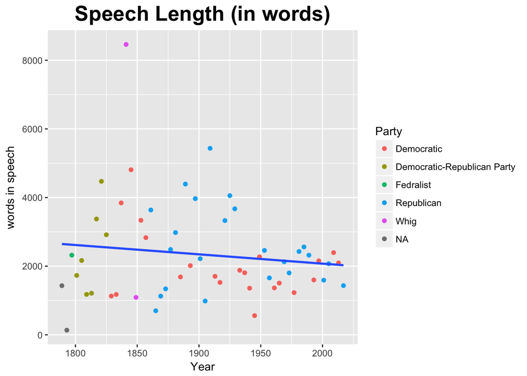

```r
#plot the speech length vs year
ggplot(data = speech.list)+
  geom_point(mapping = aes(x=year,y=Words,color=Party))+
  geom_smooth(mapping = aes(x=year,y=Words),method="lm",se=F)+
  labs(list(title = "Speech Length (in words)", x = "Year", y = "words in speech"))+
  theme(plot.title = element_text(size = 20, face = "bold",hjust = 0.5))
```

We can tell there is a slight trend that the length of speech is getting shorter.

Also, I found some “outliers” in the picture.

```r
speech.list[which.max(speech.list$Words),c("President","year","Words")]
```

```
##                 President year Words
## 14 William Henry Harrison 1841  8460
```

```r
speech.list[which.min(speech.list$Words),c("President","year","Words")]
```

```
##           President year Words
## 2 George Washington 1793   135
```

For example, the longest inaugural address is William H. Harrison’s in 1841, which amounts to 8,460 words. The shortest one is George Washington’s in 1793, which is only 135 words.

I try to get rid of them, however, the overall pattern doesn’t change much. Namely, the length of an inaugurant speech keeps getting shorter gradually:

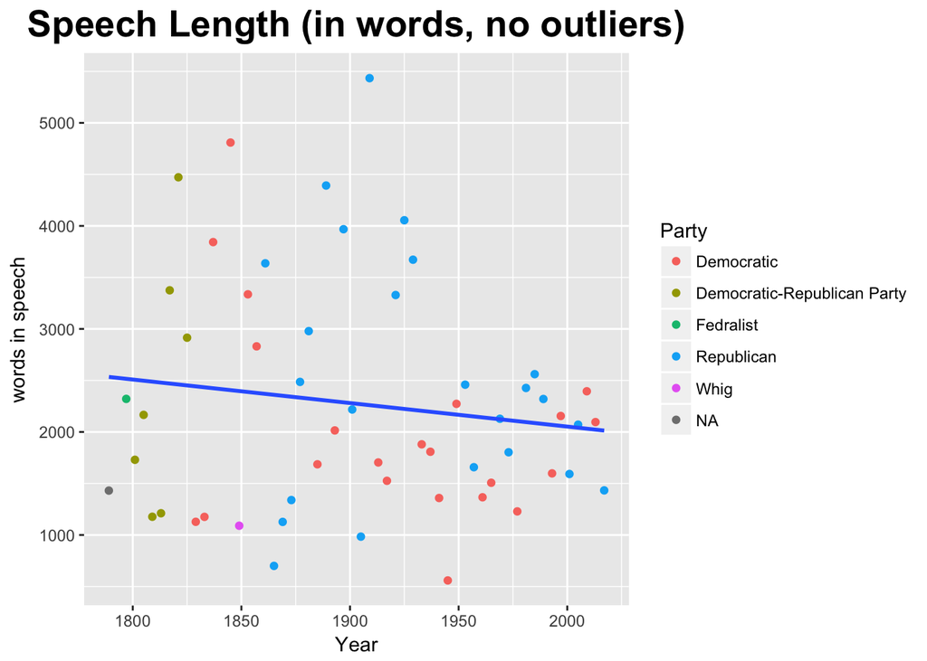

```r
speech.list.new=speech.list[-which.max(speech.list$Words),]
speech.list.new=speech.list.new[-which.min(speech.list.new$Words),]

#plot the speech length (without outliers) vs year
ggplot(data = speech.list.new)+
  geom_point(mapping = aes(x=year,y=Words,color=Party))+
  geom_smooth(mapping = aes(x=year,y=Words),method="lm",se=F)+
  labs(list(title = "Speech Length (in words, no outliers)", x = "Year", y = "words in speech"))+
  theme(plot.title = element_text(size = 20, face = "bold",hjust = 0.5))
```

## sentences amount in speech

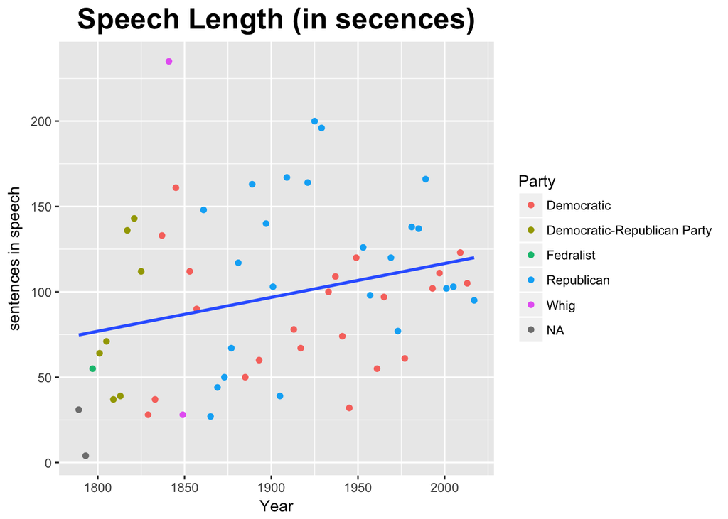

```r
speech.list$sentence=tapply(sentence.list$sent.id,sentence.list$year,length)
ggplot(data = speech.list)+
  geom_point(mapping = aes(x=year,y=sentence,color=Party))+
  geom_smooth(aes(x=year,y=sentence),se=F,method="lm")+
  labs(list(title = "Speech Length (in secences)", x = "Year", y = "sentences in speech"))+
  theme(plot.title = element_text(size = 20, face = "bold",hjust = 0.5))
```

From this point of view, the amount of setences in each speech is actually increasing. Then it easliy comes to the conclusion: every sentence contains fewer words now than before.

## average words amount in sentence

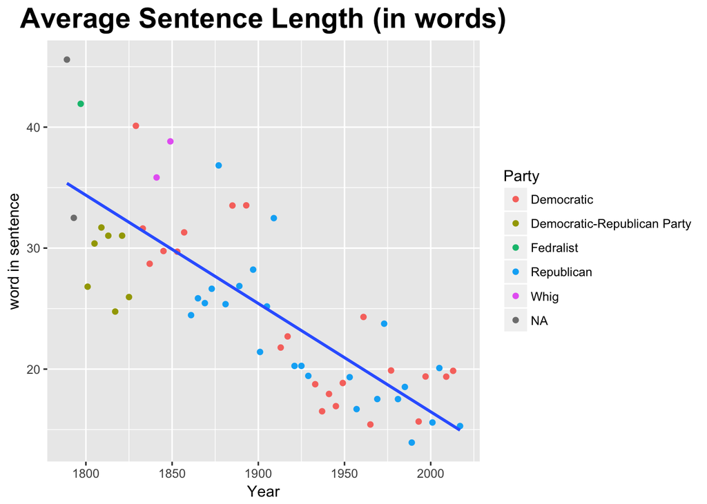

```r
speech.list$word.count=tapply(sentence.list$word.count,sentence.list$year,mean)

ggplot(data = speech.list)+
  geom_point(mapping = aes(x=year,y=word.count,color=Party))+
  geom_smooth(mapping = aes(x=year,y=word.count),se=F,method="lm")+
  labs(list(title = "Average Sentence Length (in words)", x = "Year", y = "word in sentence"))+
  theme(plot.title = element_text(size = 20, face = "bold",hjust = 0.5))
```

This pattern proves my thought. I believe the reason is that centuries or decades ago, the presidents considered their audience as people who are well-educated. However, along with the increasing voter turnout, more and more people are listening to the president speeches, among whom are some who didn’t receive good education. Therefore, presidents are tend to use simple words and simple sentences to make the speech easily understood Nowadays.

# Step 4: Data analysis: Democratic Party vs Republican Party ?

From the first picture of step 3, I found that speech lengths of presidents from Republican Party are mostly above average, meanwhile, the speech lengths of presidents who are Democrats are generally below the average. So I selet the speeches of presidents from two major party, Democratic Party and Republican Party, and try to find how does diffrent party related to the the length of sentence/speech.

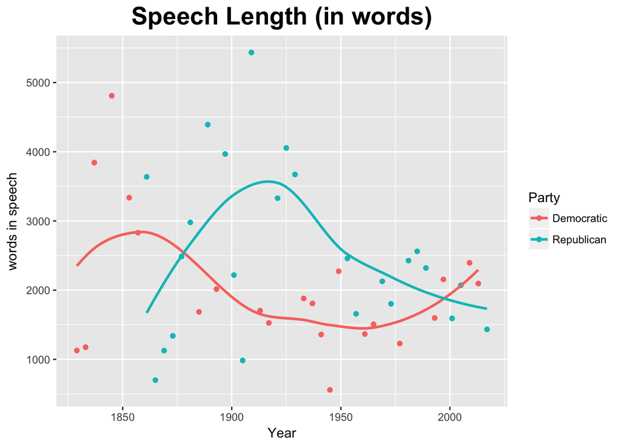

```r
Demo=speech.list[speech.list$Party=="Democratic",]
Demo=Demo[!is.na(Demo$President),]
Repub=speech.list[speech.list$Party=="Republican",]
Repub=Repub[!is.na(Repub$President),]
Demo.Repub=rbind(Demo,Repub)

ggplot(data = Demo.Repub,mapping = aes(x=year,y=Words,color=Party))+
  geom_point()+
  geom_smooth(se=F,method="loess")+
  labs(list(title = "Speech Length (in words)", x = "Year", y = "words in speech"))+
  theme(plot.title = element_text(size = 20, face = "bold",hjust = 0.5))
```

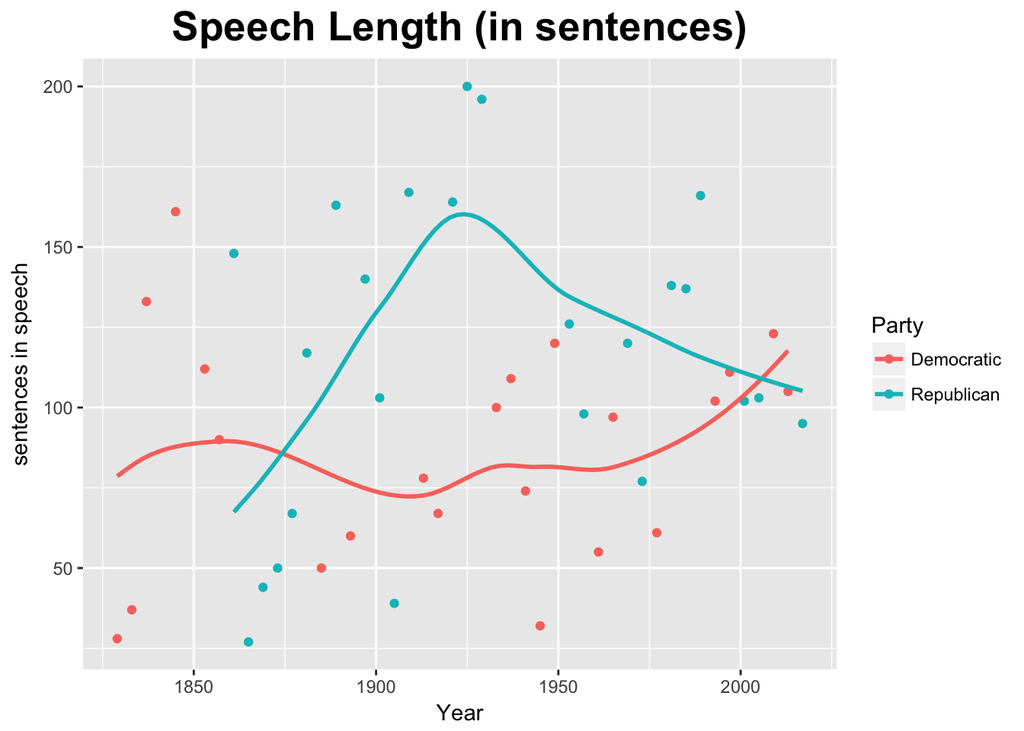

```r
ggplot(data = Demo.Repub,mapping = aes(x=year,y=sentence,color=Party))+
  geom_point()+
  geom_smooth(se=F,method="loess")+
  labs(list(title = "Speech Length (in sentences)", x = "Year", y = "sentences in speech"))+
  theme(plot.title = element_text(size = 20, face = "bold",hjust = 0.5))
```

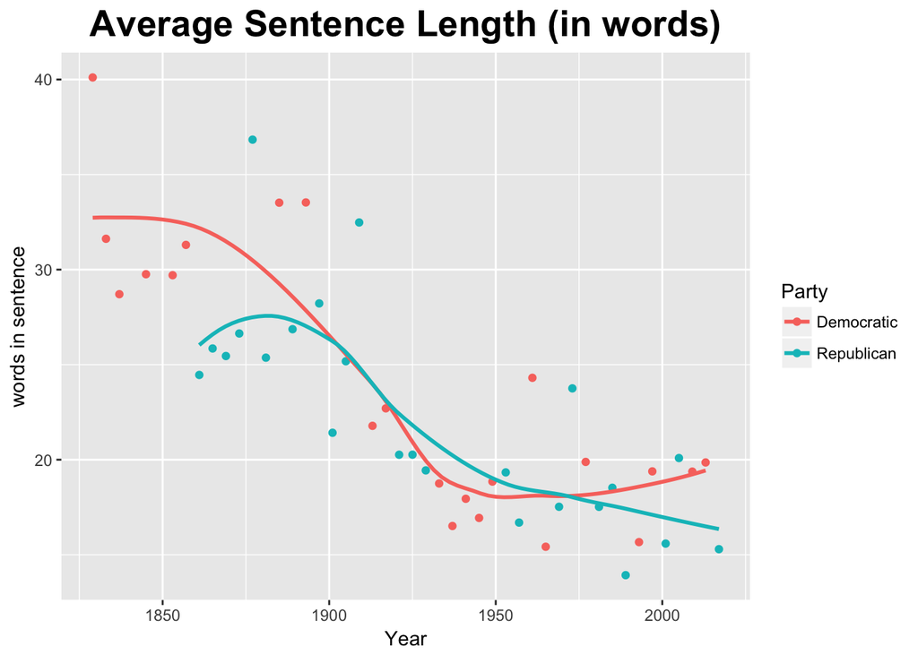

```r
ggplot(data = Demo.Repub,mapping = aes(x=year,y=word.count,color=Party))+
  geom_point()+
  geom_smooth(se=F,method="loess")+
  labs(list(title = "Average Sentence Length (in words)", x = "Year", y = "words in sentence"))+
  theme(plot.title = element_text(size = 20, face = "bold",hjust = 0.5))
```

From figures above, we can tell that Republicans are more “wordy” than the Democrats. Their speeches tend to contain more sentences and thus amount to more words. However, presidents from two parties all follow the trend that each sentence has fewer words today than before.

# Step 4: Data analysis: Word Frequency

## words frequency in all speeches

There are some words that appear in every speech. So I was wondering which words have high frequency of occurances. I load in the speeches from local folder and counted the frequency of every word.

```r
folder.path="../data/InauguralSpeeches/"
fulltext<-Corpus(DirSource(folder.path))

fulltext<-tm_map(fulltext, stripWhitespace)
fulltext<-tm_map(fulltext, content_transformer(tolower))
fulltext<-tm_map(fulltext, removeWords, stopwords("english"))
fulltext<-tm_map(fulltext, removeWords, character(0))
fulltext<-tm_map(fulltext, removePunctuation)
fulltext<-tm_map(fulltext, stemDocument)
fulltext<-tm_map(fulltext, removePunctuation)
fulltext<-tm_map(fulltext, removeNumbers)
fulltext<-tm_map(fulltext, PlainTextDocument)

dtm <- DocumentTermMatrix(fulltext)
dtms <- removeSparseTerms(dtm, 0.1)
```

Then plot the frequency of words which showed more than 200 times in all the inauguration speech. There are 29 such words in total.

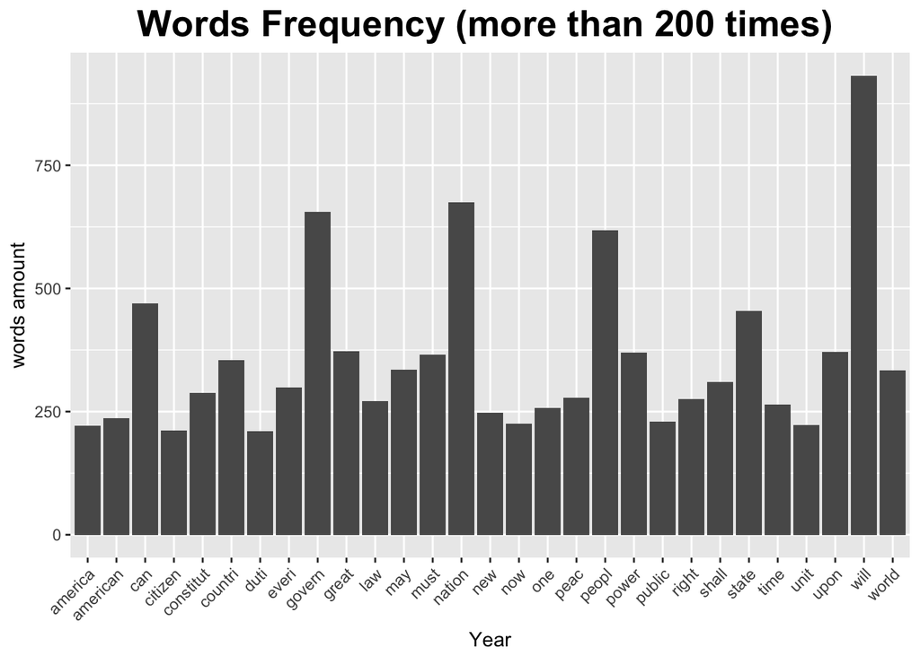

```r
freq <- sort(colSums(as.matrix(dtm)), decreasing=TRUE)
wf <- data.frame(word=names(freq), freq=freq)

ggplot(subset(wf, freq>200), aes(word, freq))+
geom_bar(stat="identity")+
theme(axis.text.x=element_text(angle=45, hjust=1),plot.title = element_text(size = 20, face = "bold",hjust = 0.5))+
labs(list(title = "Words Frequency (more than 200 times) ", x = "Year", y = "words amount"))
```

```r
nrow(subset(wf, freq>200))
```

```
## [1] 29
```

```r
wf[which.max(wf$freq),]
```

```
##      word freq
## will will  932
```

The word “will” appeared most in the speeches, with 932 times.

## frequency of certain words in every speech

In this part I try to find the frequency of certain words in every speech, to check if there is any intesting apperance. However, due to the different numbers of words each speech has, I devide the frequency by the length of speech(in words),to show how many times a word could appear in every 100 words in a speech. I take the words “people” & “govern” as an example here.

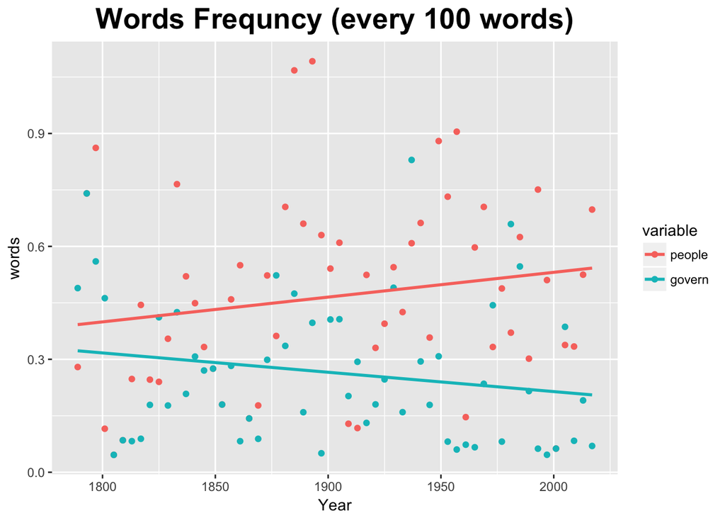

```r
#people vs govern
for (i in 1:nrow(speech.list))
     {
       speech.list$people[i]=length(gregexpr("people",speech.list$fulltext[i])[[1]])/speech.list$Words[i]*100
       speech.list$govern[i]=length(gregexpr("govern",speech.list$fulltext[i])[[1]])/speech.list$Words[i]*100
}

sublist=speech.list[,c("year","people","govern")]
sub=melt(sublist,id="year")
ggplot(data=sub)+
  geom_point(aes(x=year, y=value, colour=variable))+
  geom_smooth(aes(x=year, y=value, colour=variable),se=F,method="lm")+
  labs(list(title = "Words Frequncy (every 100 words)", x = "Year", y = "words"))+
  theme(plot.title = element_text(size = 20, face = "bold",hjust = 0.5))
```

There is a pattern that the word “people” are using more frequently while the word “govern” appears less. This may be a sign that today presidents care more about people rather than the power to govern, and the country is getting democratic.

## Who is the “greatest” president?

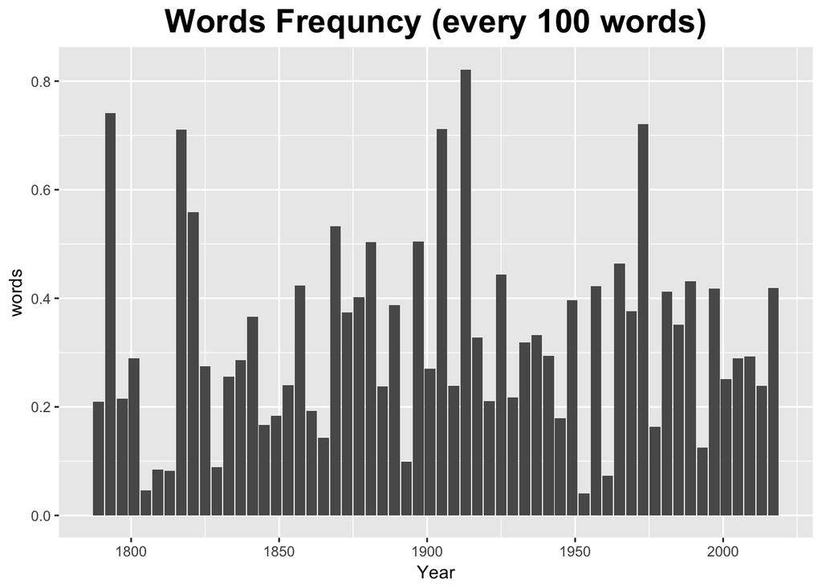

```r
for (i in 1:nrow(speech.list))
     {
       speech.list$great[i]=length(gregexpr("great",speech.list$fulltext[i])[[1]])/speech.list$Words[i]*100
}
ggplot(data=speech.list,aes(x=year,y=great))+
  geom_bar(stat="identity")+
  labs(list(title = "Words Frequncy (every 100 words)", x = "Year", y = "words"))+
  theme(plot.title = element_text(size = 20, face = "bold",hjust = 0.5))
```

```r
speech.list[which.max(speech.list$great),c("President","Date","great")]
```

```
##         President          Date     great
## 32 Woodrow Wilson March 4, 1913 0.8215962
```

President Woodrow Wilson’s speech used more than 1 “great” among 120 words.